# 3. Results Analysis and Visualization

### 5.5.2 GR Value

#### 5.5.2.1 CAMA-1

🔍 Zoom In for Details

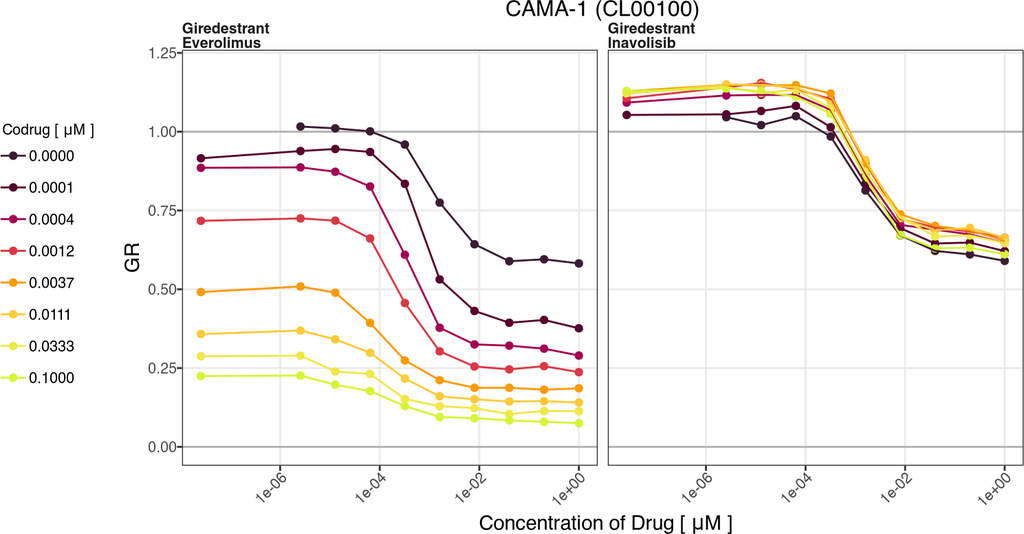

#### 5.5.2.2 EFM-19

🔍 Zoom In for Details

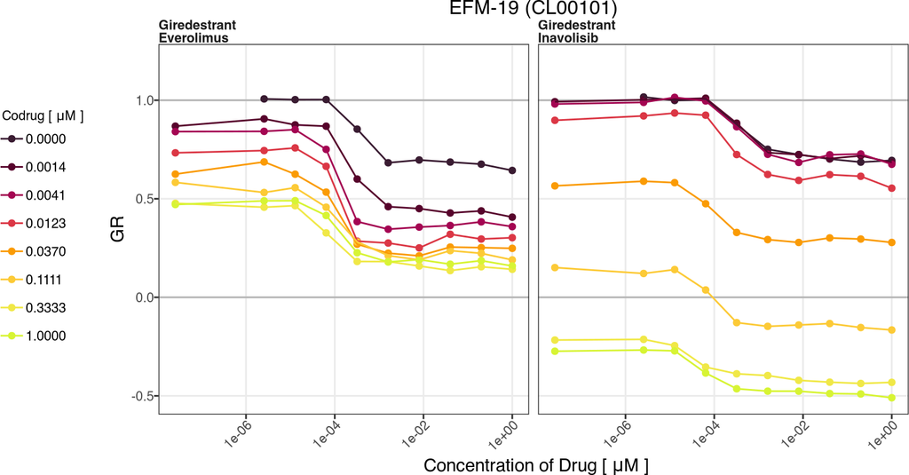

#### 5.5.2.3 MCF-7

🔍 Zoom In for Details

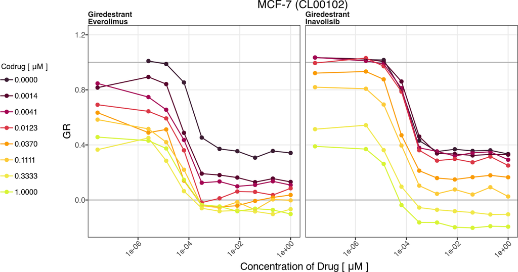

#### 5.5.2.4 T-47D

🔍 Zoom In for Details

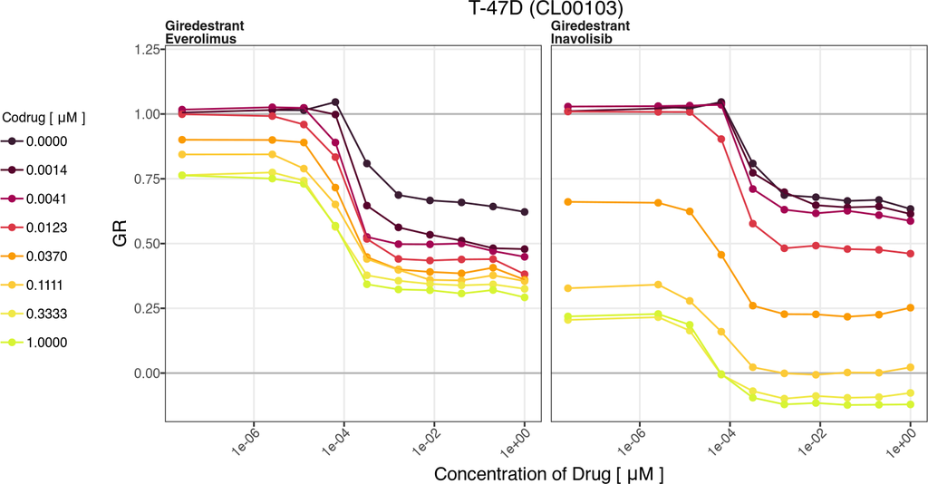